# Assignment 6

Michelle

4/20/2020

```r
#devtools::install_github("bomeara/geiger")
library ("ape")
library ("corHMM")
library("geiger")
library("phangorn")
library("openxlsx")
library("rotl")
library("phytools")
```

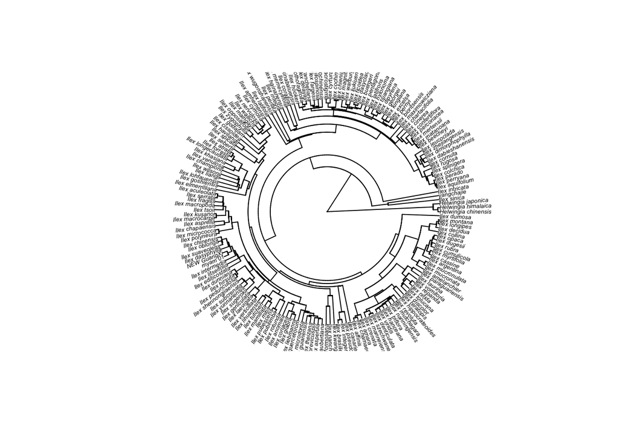

```r
hollies <- get_study_tree("ot_1984", "tree1")
hollies.study.metadat<-get_study_meta("ot_1984")
hollies.tree.ids<-get_tree_ids(hollies.study.metadat)
plot(hollies, type="fan", cex = 0.4)
```

## You’ll need to get data into R in some way. Look at other phylometh assignments for how to #get trees and data.

```r
hollies <- get_study_tree("ot_1984", "tree1")
print (hollies)
```

```
##
## Phylogenetic tree with 175 tips and 174 internal nodes.
##
## Tip labels:
##  Helwingia_chinensis, Helwingia_himalaica, Helwingia_japonica, Ilex_sinica, yangchajie, Ilex_intricata, ...
##
## Rooted; includes branch lengths.
```

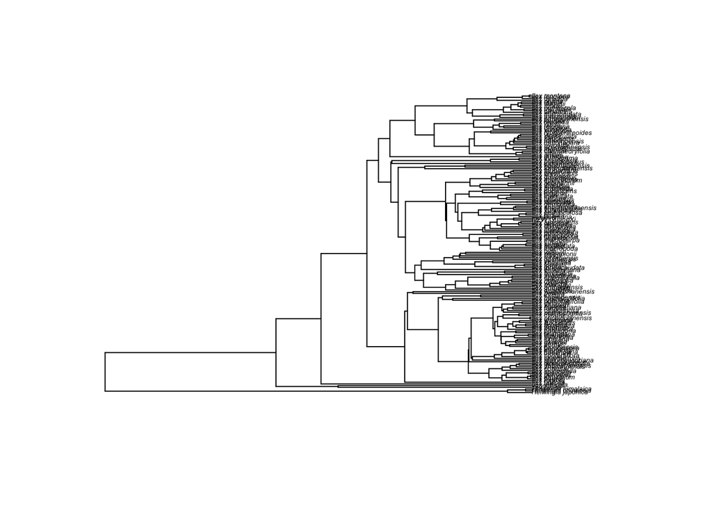

```r
hollies.study.metadat<-get_study_meta("ot_1984")
hollies.tree.ids<-get_tree_ids(hollies.study.metadat)
plot(hollies, cex = 0.4)
```

```r
setwd("~/phylometh_exercises-/data\ set\ 6\ and\ 7")

hollies.data <- read.xlsx (xlsxFile = "hollies.xlsx", startRow = 2)
head(hollies.data )
```

```
##                                  species colour fruit.diameter.(mm)  margin
## 1                  Ilex aculeolata Nakai  black                 7.0 serrate
## 2                   Ilex affinis Gardner  black                 4.0 serrate
## 3                       Ilex amara Loes.    red                 5.5 serrate
## 4 Ilex amelanchier M.A. Curtis ex Chapm.    red                 7.5  entire
## 5              Ilex anomala Hook. & Arn.  black                 9.0  entire
## 6                     Ilex aquifolium L.    red                 8.0   spiny
##   maximum.height.(m)
## 1                  4
## 2                  6
## 3                  4
## 4                  2
## 5                  9
## 6                 25
```

```r
#Take the first 2 names and anytime there is an "_" it will split and put it together.
GetGenusSpeciesOneTaxon <- function(x) {
  x <- gsub("_", " ", x)
  x <- strsplit(x, "\\s+")[[1]]
  return(paste0(x[1:2], collapse="_"))
}
GetGenusSpeciesManyTaxa <- function(x) {
  return(unname(sapply(x, GetGenusSpeciesOneTaxon)))
}
# To get ride of the space and replace it with an "_"
hollies.data$species <- GetGenusSpeciesManyTaxa(gsub(" ", "_", hollies.data$species))

head(hollies.data )
```

```
##            species colour fruit.diameter.(mm)  margin maximum.height.(m)
## 1  Ilex_aculeolata  black                 7.0 serrate                  4
## 2     Ilex_affinis  black                 4.0 serrate                  6
## 3       Ilex_amara    red                 5.5 serrate                  4
## 4 Ilex_amelanchier    red                 7.5  entire                  2
## 5     Ilex_anomala  black                 9.0  entire                  9
## 6  Ilex_aquifolium    red                 8.0   spiny                 25
```

```r
#To read csv files
#discrete.data <- read.csv(file= "hollies.xlsx", stringsAsFactors=FALSE)
```

#To get the color data

```r
hollies.colour <- hollies.data$colour
names(hollies.colour) <- hollies.data$species
print(head(hollies.colour))
```

```
##  Ilex_aculeolata     Ilex_affinis       Ilex_amara Ilex_amelanchier
##          "black"          "black"            "red"            "red"
##     Ilex_anomala  Ilex_aquifolium
##          "black"            "red"
```

```r
print(hollies.colour)
```

[output not shown]

[output cut: 59 more lines]

[output not shown]

```r
table(hollies.colour)
```

```
## hollies.colour
## black brown    na   red
##    26     3    30   110
```

```r
is.na(hollies.colour)
```

[output not shown]

[output cut: 59 more lines]

[output not shown]

```r
na.omit(hollies.colour)
```

[output not shown]

[output cut: 59 more lines]

[output not shown]

```r
hollies.colour <- hollies.colour[!grepl("na", hollies.colour)]
```

# Cleaning your data (Taxa and data match up)

# Now write the code to use CleanData() to actually clean your data

#CleanData <- function(phy,data) { #return(treedata(phy, data)) #} #Data are often not right in some way. They might not match the taxa in your tree, there may #be missing data, etc. #geiger::treedata is a great function for getting a tree and data that #match, but your data may need other cleaning. #Do it as a function so it’s repeatable.

```r
CleanData <- function(phy, data) {
 #result=treedata(phy, data,sort = TRUE, warnings = FALSE)
  #return(result) or the function below
  return(treedata(phy, data,sort = TRUE, warnings = FALSE))
}
hollies.cleaned<-CleanData(hollies, hollies.colour)
print(str(hollies.cleaned))
```

```
## List of 2
##  $ phy :List of 4
##   ..$ edge       : int [1:268, 1:2] 136 136 137 137 138 139 139 140 141 142 ...
##   ..$ tip.label  : chr [1:135] "Ilex_sinica" "Ilex_intricata" "Ilex_aquifolium" "Ilex_perryana" ...
##   ..$ Nnode      : int 134
##   ..$ edge.length: num [1:268] 50.75 8.94 41.8 9.11 7.5 ...
##   ..- attr(*, "class")= chr "phylo"
##   ..- attr(*, "order")= chr "cladewise"
##  $ data: chr [1:135, 1] "red" "red" "red" "red" ...
##   ..- attr(*, "dimnames")=List of 2
##   .. ..$ : chr [1:135] "Ilex_sinica" "Ilex_intricata" "Ilex_aquifolium" "Ilex_perryana" ...
##   .. ..$ : NULL
## NULL
```

#VisualizeData <- function(phy, data) { #Important here is to LOOK at your data before running it. Any weird values? Does it all make sense? What about #your #tree? Polytomies? # Now write the code to use VisualizeData() to actually look at your data #}

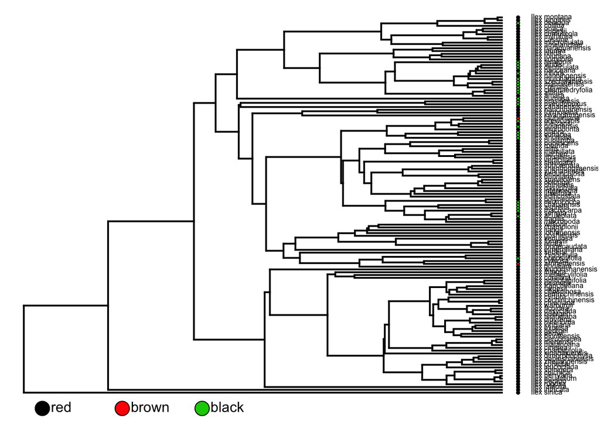

```r
VisualizeData <- function(phy, data) {
  dotTree(phy,data, fsize=0.5,lwd=2)
}
VisualizeData(phy=hollies.cleaned$phy,data=hollies.cleaned$data)
```

#First, let’s use parsimony to look at ancestral states:

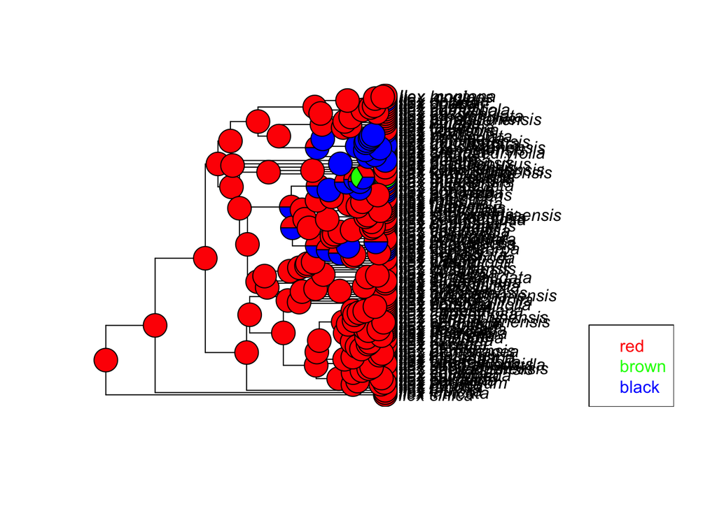

```r
cleaned.discrete.phyDat <- phangorn::phyDat(hollies.cleaned$data, type="USER",levels = c("red", "brown","black"))
#phyDat is a data format used by phangorn
anc.p <- phangorn::ancestral.pars(hollies.cleaned$phy, cleaned.discrete.phyDat)
plotAnc(hollies.cleaned$phy, anc.p, 1)
```

#Now, plot the likelihood estimates.

```r
class(hollies.cleaned$data)
Dat<-as.phyDat(hollies.cleaned$data, type="USER", levels = c("black", "brown","red"))
anc.ml <- ancestral.pml(pml(hollies.cleaned$phy, Dat), type="ml")
plotAnc(hollies.cleaned$phy, anc.ml, 1)
print(Dat)
```

[output not shown]

```r
Dat<-as.phyDat(hollies.cleaned$data, type="USER", levels = c("black", "brown","red"))
```